# Trabajo Grupal R

Haciendo uso de los mismos paquetes, se logró graficar la participación promedio de las transferencias en la suma del monto de inversión de los proyectos de inversión pública. En ese sentido, se puede observar que las transferencias alcanzan a cubrir gran parte del monto de inversión de los proyectos. También se puede observar que hay regiones cuyo monto transferido supera en promedio el monto de inversión de los proyectos de inversión de dicho departamento. Adicionalmente, a partir de una mirada general, se puede observar que los departamentos cercanos a la costa (tanto del norte del sur, a excepción de Puno, Ayacucho, Amazonas y Cajamarca) lograron cubrir un mayor porcentaje de la inversión de sus proyectos, con las transferencias del Gobierno Nacional.

```r
bd_reactiva_pyto <- cbind(bd_reactiva_pyto, PorcCostoAsumido=c(bd_reactiva_pyto$MONTODETRANSFERENCIA2020 / bd_reactiva_pyto$MONTODEINVERSIÓN))
```

```r
TABLA3 <-bd_reactiva_pyto %>%
  group_by(REGION) %>%
  summarise(PromedioPorceAsumido=mean(PorcCostoAsumido))
```

```r
nuevafila3=data.frame(REGION="Madre de Dios", PromedioPorceAsumido=NA)
TABLA3=rbind(TABLA3,nuevafila3)
```

```r
library(dplyr)
library(sf)
df3 <- left_join(df, TABLA3, by="REGION")
str(TABLA3)
```

```
## tibble [26 × 2] (S3: tbl_df/tbl/data.frame)
##  $ REGION              : chr [1:26] "Amazonas" "Áncash" "Apurímac" "Arequipa" ...
##  $ PromedioPorceAsumido: num [1:26] 0.909 0.925 0.831 0.936 0.941 ...
```

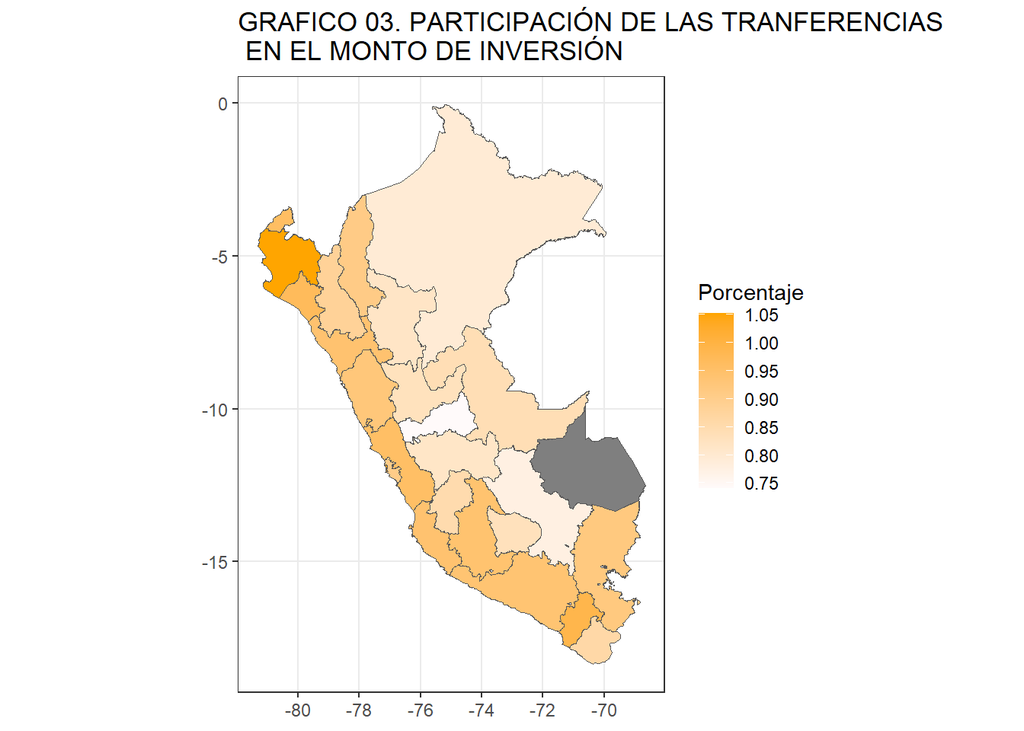

```r
library(ggplot2)

ggplot(df3, aes(geometry=geometry)) +
  geom_sf(aes(fill=PromedioPorceAsumido)) +
  theme_bw() +
  labs(fill = "Porcentaje ")+
  labs(title = "GRAFICO 03. PARTICIPACIÓN DE LAS TRANFERENCIAS \n EN EL MONTO DE INVERSIÓN")+
  #theme(plot.title = element_text(hjust = 0.5)) +
  scale_fill_gradient (low="snow", high="orange")
```

> Población beneficiada en relación a la totalidad de su población de los proyectos concluídos

El porcentaje de población beneficiada en la mayoría de regiones es bajo, siendo en promedio entre las 25 regiones analizadas 8.9%. Sin embargo, las regiones con mayor porcentaje de población beneficiada sí muestran importantes cifras. Lima Provincias y Ayacucho, segunda y tercera región con mayor porcentaje de población beneficiada respectivamente, llegan alrededor del 25%; es decir, alrededor de una cuarta parte de la población de distritos con proyectos concluidos como beneficiada.

Asimismo, la región con mayor porcentaje es Apurímac, llegando con 38.3% a más de un tercio de la población de sus distritos analizados como beneficiada por los proyectos concluidos. Por otro lado, la regiones de Tumbes, Loreto, La Libertad, Callao, Moquegua y Ucayali presentan menos del 2% de su población beneficiada en distritos con proyectos concluidos.

Así, si bien no hay un patrón absoluto se puede reconocer que la zonas Norte y Oriente del país han tenido una menor proporción de su población beneficiada en distritos con proyectos concluidos. A esta zona le seguiría la zona Sur del país; mientras que, la zona Centro sería la de mayor proporción de población beneficiada.

Los factores que han llevado a esa diferencia entre las zonas del país pueden ser diversos, entre ellas proyectos más pequeños desarrollados en las zonas menos beneficiadas, menor cantidad de recursos dispuestos para esas zonas, menor capacidad de las municipalidades locales para concluir los proyectos, entre otros.

```r
# Porcentaje de población beneficiaria por región y por proyectos concluidos ----

library(readr)
link<- ("https://raw.githubusercontent.com/Diane-12/BD_Pytoreactiva/main/reporte.csv")
#str(object=bd_reactiva_pyto)
pob <- read.csv(link)
#sapply(bd_reactiva_pyto, class) #para conocer las clases de cada variable

bdpob<-bd_reactiva_pyto |>
  left_join(pob[c(1,2,5,6,7)], by= "UBIGEO", "COD_PROVINCIA")


pb_reg<-bdpob |>
  group_by(REGION) |>
  summarize(pob_ben=sum(`POBLACIONBENEFICIARIA`[`ESTADO`=="Concluido"]),
            pob_reg=mean(POB_REG[`ESTADO`=="Concluido"]))

pb_reg<-pb_reg |>
  mutate(porc_pb=(pob_ben/pob_reg)*100)

nuevafila2=data.frame(REGION="Madre de Dios", pob_ben=NA, pob_reg=NA, porc_pb=NA)
pb_reg=rbind(pb_reg,nuevafila2)

pb_reg2 <- left_join(pb_reg, df, by="REGION")
str(pb_reg2)
```

```
## tibble [26 × 8] (S3: tbl_df/tbl/data.frame)
##  $ REGION    : chr [1:26] "Amazonas" "Áncash" "Apurímac" "Arequipa" ...
##  $ pob_ben   : int [1:26] 6262 5923 7258 9564 41014 53674 6911 5972 5096 5750 ...
##  $ pob_reg   : num [1:26] 64242 65550 18937 341534 170131 ...
##  $ porc_pb   : num [1:26] 9.75 9.04 38.33 2.8 24.11 ...
##  $ COD_REGION: chr [1:26] "010000" "020000" "030000" "040000" ...
##  $ coords_x  : num [1:26] -78.1 -77.7 -73 -72.5 -74.1 ...
##  $ coords_y  : num [1:26] -5.07 -9.41 -14.03 -15.84 -14.09 ...
##  $ geometry  :sfc_MULTIPOLYGON of length 26; first list element: List of 1
##   ..$ :List of 1
##   .. ..$ : num [1:1285, 1:2] -77.6 -77.6 -77.6 -77.6 -77.6 ...
##   ..- attr(*, "class")= chr [1:3] "XY" "MULTIPOLYGON" "sfg"
```

```r
pb_reg2$porc_pb
```

```
##  [1]  9.7475172  9.0358505 38.3270845  2.8003069 24.1073055 12.0170694
##  [7]  1.3136011  4.3499162 12.5138128  4.9997826  6.3179476 12.1630682
## [13]  1.6071149  2.4577122  2.0967542 28.1334016  1.9665816  1.1447224
## [19] 20.9206801  2.9180092  4.1942375 13.0554121  2.7484506  1.9730678
## [25]  0.4488459         NA
```

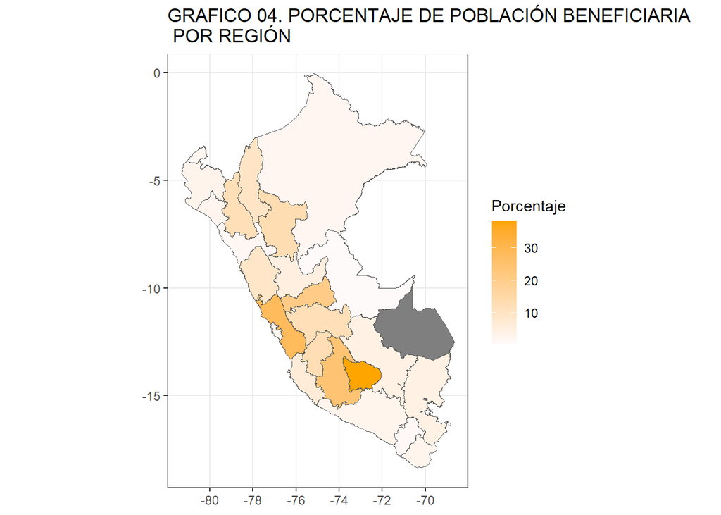

```r
library(ggplot2)
ggplot(pb_reg2, aes(geometry=geometry)) +
  geom_sf(aes(fill=porc_pb)) +
  theme_bw() +
  labs(fill = "Porcentaje ")+
  labs(title = "GRAFICO 04. PORCENTAJE DE POBLACIÓN BENEFICIARIA \n POR REGIÓN")+
  scale_fill_gradient (low="snow", high="orange")
```

> Número de Proyectos por tipo de intervención.

Del total de 525 proyectos de inversión pública a nivel nacional, el 85% (447) corresponde a “Pista y vereda”, el 14,5% (76) a “Equipamiento urbano” y menos del 1% a “Puentes”.

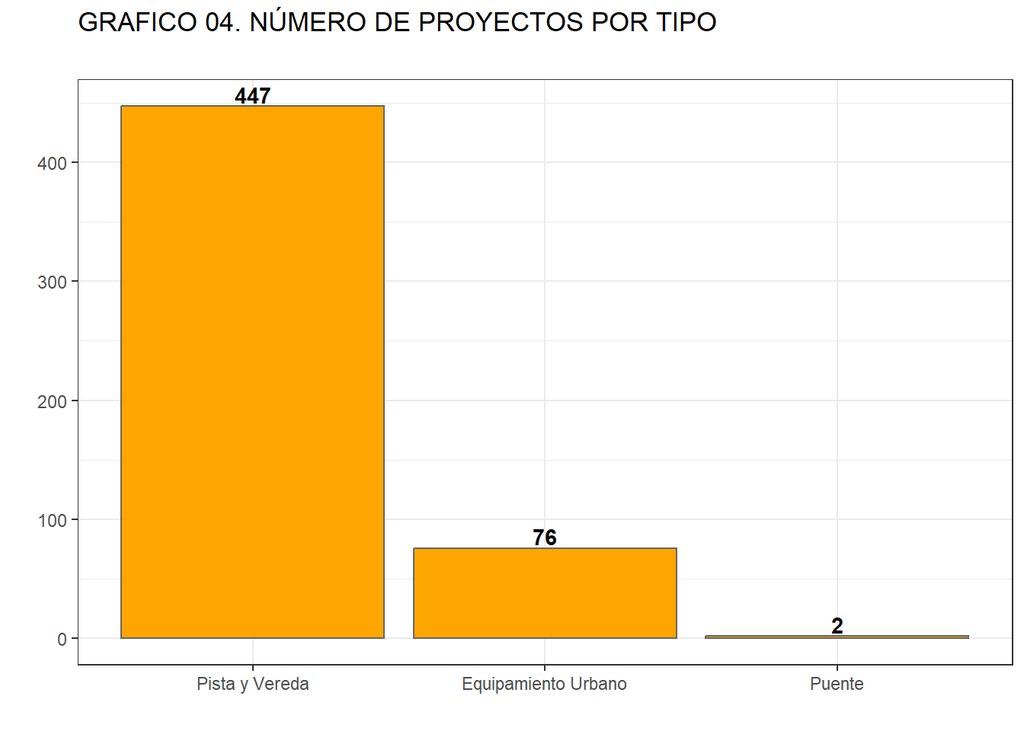

```r
bd_reactiva_pyto %>%
  group_by(TIPOLOGIA) %>%
  summarise(count=n()) %>%
  ggplot(aes(x=reorder(TIPOLOGIA, (-count)), y=count)) +
  geom_col(colour="black") +
  geom_bar(stat = "identity", fill="orange", color="grey40") +
  theme_bw() +
  #coord_flip() +
  geom_text(aes(label=after_stat(y), fontface= "bold"), vjust=-0.2) +
  theme(legend.title = element_blank()) +
  labs(x=" ", y=" ", title = "GRAFICO 04. NÚMERO DE PROYECTOS POR TIPO", subtitle= " ")
```

Del total de 525 proyectos de inversión pública a nivel nacional, el 85% (447) corresponde a “Pista y vereda”, el 14,5% (76) a “Equipamiento urbano” y menos del 1% a “Puentes”.